# RNA-Seq Workflow Template

Author: First Last Name

Last update: 13 May, 2026

#### Package

systemPipeR 2.18.0

# 1 Introduction

## 1.1 Overview

This workflow template is for analyzing RNA-Seq data. It is provided by [systemPipeRdata](https://bioconductor.org/packages/devel/data/experiment/html/systemPipeRdata.html), a companion package to [systemPipeR](https://www.bioconductor.org/packages/devel/bioc/html/systemPipeR.html) (H Backman and Girke 2016; Zhang et al. 2026). Similar to other `systemPipeR` workflow templates, a single command generates the necessary working environment. This includes the expected directory structure for executing `systemPipeR` workflows and parameter files for running command-line (CL) software utilized in specific analysis steps. For learning and testing purposes, a small sample (toy) data set is also included (mainly FASTQ and reference genome files). This enables users to seamlessly run the numerous analysis steps of this workflow from start to finish without the requirement of providing custom data. After testing the workflow, users have the flexibility to employ the template as is with their own data or modify it to suit their specific needs. For more comprehensive information on designing and executing workflows, users want to refer to the main vignettes of [systemPipeR](https://www.bioconductor.org/packages/devel/bioc/vignettes/systemPipeR/inst/doc/systemPipeR.html) and [systemPipeRdata](https://www.bioconductor.org/packages/devel/data/experiment/vignettes/systemPipeRdata/inst/doc/systemPipeRdata.html).

The `Rmd` file (`systemPipeRNAseq.Rmd`) associated with this vignette serves a dual purpose. It acts both as a template for executing the workflow and as a template for generating a reproducible scientific analysis report. Thus, users want to customize the text (and/or code) of this vignette to describe their experimental design and analysis results. This typically involves deleting the instructions how to work with this workflow, and customizing the text describing experimental designs, other metadata and analysis results.

## 1.2 Experimental design

Typically, the user wants to describe here the sources and versions of the reference genome sequence along with the corresponding annotations. The standard directory structure of `systemPipeR` (see [here](https://www.bioconductor.org/packages/devel/bioc/vignettes/systemPipeR/inst/doc/systemPipeR.html#3_Directory_structure)), expects the input data in a subdirectory named `data` and all results will be written to a separate `results` directory. The Rmd source file for executing the workflow and rendering its report (here `systemPipeRNAseq.Rmd`) is expected to be located in the parent directory.

The test (toy) data set used by this template (SRP010938) contains 18 paired-end (PE) read sets from *Arabidposis thaliana* (Howard et al. 2013). To minimize processing time during testing, each FASTQ file has been reduced to 90,000-100,000 randomly sampled PE reads that map to the first 100,000 nucleotides of each chromosome of the *A. thaliana* genome. The corresponding reference genome sequence (FASTA) and its GFF annotation files have been reduced to the same genome regions. This way the entire test sample data set is less than 200MB in storage space. A PE read set has been chosen here for flexibility, because it can be used for testing both types of analysis routines requiring either SE (single end) reads or PE reads.

To use their own RNA-Seq and reference genome data, users want to move or link the data to the designated `data` directory and execute the workflow from the parent directory using their customized `Rmd` file. Beginning with this template, users should delete the provided test data and move or link their custom data to the designated locations. Alternatively, users can create an environment skeleton (named `new` [here](https://www.bioconductor.org/packages/devel/data/experiment/vignettes/systemPipeRdata/inst/doc/new.html)) or build one from scratch. To perform an RNA-Seq analysis with new FASTQ files from the same reference genome, users only need to provide the FASTQ files and an experimental design file called ‘targets’ file that outlines the experimental design. The structure and utility of targets files is described in `systemPipeR's` main vignette [here](https://www.bioconductor.org/packages/devel/bioc/vignettes/systemPipeR/inst/doc/systemPipeR.html#4_The_targets_file).

## 1.3 Workflow steps

The default analysis steps included in this RNA-Seq workflow template are listed below. Users can modify the existing steps, add new ones or remove steps as needed.

**Default analysis steps**

1. Read preprocessing
   - Quality filtering (trimming)
   - FASTQ quality report
2. Alignments: *`HISAT2`* (or any other RNA-Seq aligner)
3. Alignment stats
4. Read counting
5. Sample-wise correlation analysis
6. Analysis of differentially expressed genes (DEGs)
7. GO term enrichment analysis
8. Gene-wise clustering

## 1.4 Load workflow environment

The environment for this RNA-Seq workflow is auto-generated below with the `genWorkenvir_gh` function. It is fully populated with a small test data set, including FASTQ files, reference genome and annotation data. The name of the resulting workflow directory can be specified under the `mydirname` argument. The default `NULL` uses the name of the chosen workflow. An error is issued if a directory of the same name and path exists already. After this, the user’s R session needs to be directed into the resulting `rnaseq` directory (here with `setwd`) and the `systemPipeRNAseq.Rmd` source file opened that provides the code of this workflow. This file is located within the `rnaseq` directory.

```r
library(systemPipeRdata)
genWorkenvir_gh(url = "https://github.com/GEN242-2026/sprwf-rnaseq-gen242-2026.git",
    mydirname = "rnaseq")
setwd("rnaseq")
getParam_gh()
getData_gh()
```

### 1.4.1 Input data: `targets` file

The `targets` file defines the input files (e.g. FASTQ or BAM) and sample comparisons used in a data analysis workflow. It can also store any number of additional descriptive information for each sample. The following shows the first four lines of the `targets` file used in this workflow template.

```r
targetspath <- system.file("extdata", "targetsPE.txt", package = "systemPipeR")
targets <- read.delim(targetspath, comment.char = "#")
targets[1:4, -c(5, 6)]
```

```
##                     FileName1                   FileName2
## 1 ./data/SRR446027_1.fastq.gz ./data/SRR446027_2.fastq.gz
## 2 ./data/SRR446028_1.fastq.gz ./data/SRR446028_2.fastq.gz
## 3 ./data/SRR446029_1.fastq.gz ./data/SRR446029_2.fastq.gz
## 4 ./data/SRR446030_1.fastq.gz ./data/SRR446030_2.fastq.gz
##   SampleName Factor        Date
## 1        M1A     M1 23-Mar-2012
## 2        M1B     M1 23-Mar-2012
## 3        A1A     A1 23-Mar-2012
## 4        A1B     A1 23-Mar-2012
```

To work with custom data, users need to generate a *`targets`* file containing the paths to their own FASTQ files. [Here](https://www.bioconductor.org/packages/devel/bioc/vignettes/systemPipeR/inst/doc/systemPipeR.html#4_The_targets_file) is a detailed description of the structure and utility of `targets` files.

# 2 Quick start

After a workflow environment has been created with the above `genWorkenvir` function call and the corresponding R session directed into the resulting directory (here `rnaseq`), the `SPRproject` function is used to initialize a new workflow project instance. The latter creates an empty `SAL` workflow container (below `sal`) and at the same time a linked project log directory (default name `.SPRproject`) that acts as a flat-file database of a workflow. Additional details about this process and the SAL workflow control class are provided in `systemPipeR's` main vignette [here](https://www.bioconductor.org/packages/devel/bioc/vignettes/systemPipeR/inst/doc/systemPipeR.html#11_Workflow_control_class) and [here](https://www.bioconductor.org/packages/devel/bioc/vignettes/systemPipeR/inst/doc/systemPipeR.html#5_Detailed_tutorial).

Next, the `importWF` function imports all the workflow steps outlined in the source Rmd file of this vignette (here `systemPipeRNAseq.Rmd`) into the `SAL` workflow container. An overview of the workflow steps and their status information can be returned at any stage of the loading or run process by typing `sal`.

```r
library(systemPipeR)
sal <- SPRproject()
# sal <- SPRproject(resume=TRUE, load.envir=TRUE) #
# Restarts workflow.  sal <- SPRproject(overwrite=TRUE) #
# Resets workflow, meaning previous work will be erased
sal <- importWF(sal, file_path = "systemPipeRNAseq.Rmd", verbose = FALSE)
sal
```

After loading the workflow into `sal`, it can be executed from start to finish (or partially) with the `runWF` command. Running the workflow will only be possible if all dependent CL software is installed on a user’s system. Their names and availability on a system can be listed with `listCmdTools(sal, check_path=TRUE)`. For more information about the `runWF` command, refer to the help file and the corresponding section in the main vignette [here](https://www.bioconductor.org/packages/devel/bioc/vignettes/systemPipeR/inst/doc/systemPipeR.html#61_Overview).

Running workflows in parallel mode on computer clusters is a straightforward process in `systemPipeR`. Users can simply append the resource parameters (such as the number of CPUs) for a cluster run to the `sal` object after importing the workflow steps with `importWF` using the `addResources` function. More information about parallelization can be found in the corresponding section at the end of this vignette here and in the main vignette [here](https://www.bioconductor.org/packages/devel/bioc/vignettes/systemPipeR/inst/doc/systemPipeR.html#63_Parallel_evaluation).

```r
sal <- runWF(sal)
```

Workflows can be visualized as topology graphs using the `plotWF` function.

```r
plotWF(sal)
```

[interactive chart not shown]

Scientific and technical reports can be generated with the `renderReport` and `renderLogs` functions, respectively. Scientific reports can also be generated with the `render` function of the `rmarkdown` package. The technical reports are based on log information that `systemPipeR` collects during workflow runs.

```r
# Scientific report
rmarkdown::render("systemPipeRNAseq.Rmd", clean = TRUE, output_format = "BiocStyle::html_document")

# Technical (log) report
sal <- renderLogs(sal)
```

The `statusWF` function returns a status summary for each step in a `SAL` workflow instance.

```r
statusWF(sal)
```

# 3 Workflow steps

The data analysis steps of this workflow are defined by the following workflow code chunks. They can be loaded into `SAL` interactively, by executing the code of each step in the R console, or all at once with the `importWF` function used under the Quick start section. R and CL workflow steps are declared in the code chunks of `Rmd` files with the `LineWise` and `SYSargsList` functions, respectively, and then added to the `SAL` workflow container with `appendStep<-`. Their syntax and usage is described [here](https://www.bioconductor.org/packages/devel/bioc/vignettes/systemPipeR/inst/doc/systemPipeR.html#52_Constructing_workflows).

## 3.1 Load packages

The first step loads the `systemPipeR` package.

```r
cat(crayon::blue$bold("To use this workflow, the following R packages are required:\n"))
cat(c("'GenomicFeatures", "BiocParallel", "DESeq2", "ape", "edgeR",
    "biomaRt", "pheatmap", "ggplot2'\n"), sep = "', '")
### pre-end
appendStep(sal) <- LineWise(code = {
    library(systemPipeR)
}, step_name = "load_SPR")
```

## 3.2 Read preprocessing

### 3.2.1 With `preprocessReads`

The `preprocessReads` function allows applying predefined or custom read preprocessing functions to all FASTQ files referenced in a SAL container, such as quality filtering or adapter trimming routines. Internally, `preprocessReads` uses the `FastqStreamer` function from the `ShortRead` package to stream through large FASTQ files in a memory-efficient manner. The following example uses `preprocessReads` to perform adapter trimming with the `trimLRPatterns` function from the `Biostrings` package. In this instance, `preprocessReads` is invoked through a CL interface built on `docopt`, that is executed from R with CWL. The parameters for running `preprocessReads` are specified in the corresponding `cwl/yml` files. It is important to point out that creating and using CL interfaces for defining R-based workflow steps is not essential in `systemPipeR` since [`LineWise`](https://www.bioconductor.org/packages/devel/bioc/vignettes/systemPipeR/inst/doc/systemPipeR.html#5211_Step_1:_R_step) offers similar capabilities while requiring less specialized knowledge from users.

```r
appendStep(sal) <- SYSargsList(step_name = "preprocessing", targets = "targetsPE.txt",
    dir = TRUE, wf_file = "preprocessReads/preprocessReads-pe.cwl",
    input_file = "preprocessReads/preprocessReads-pe.yml", dir_path = system.file("extdata/cwl",
        package = "systemPipeR"), inputvars = c(FileName1 = "_FASTQ_PATH1_",
        FileName2 = "_FASTQ_PATH2_", SampleName = "_SampleName_"),
    dependency = c("load_SPR"))
```

The paths to the output files generated by the preprocessing step (here trimmed FASTQ files) are recorded in a new `targets` file that can be used for the next workflow step, *e.g.* running the NGS alignments with the trimmed FASTQ files.

The following example demonstrates how to design a custom `preprocessReads` function, as well as how to replace parameters in the `sal` object. To apply the modifications to the workflow, it needs to be saved to a file, here `param/customFCT.RData` which will be loaded during the workflow run by the `preprocessReads.doc.R` script. Please note, this step is included here solely for demonstration purposes, and thus not part of the workflow run. This is achieved by dropping `spr=TRUE` in the header line of the code chunk.

```r
appendStep(sal) <- LineWise(code = {
    filterFct <- function(fq, cutoff = 20, Nexceptions = 0) {
        qcount <- rowSums(as(quality(fq), "matrix") <= cutoff,
            na.rm = TRUE)
        # Retains reads where Phred scores are >= cutoff
        # with N exceptions
        fq[qcount <= Nexceptions]
    }
    save(list = ls(), file = "param/customFCT.RData")
}, step_name = "custom_preprocessing_function", dependency = "preprocessing")
```

After defining this step, it can be inspected and modified as follows.

```r
yamlinput(sal, "preprocessing")$Fct
yamlinput(sal, "preprocessing", "Fct") <- "'filterFct(fq, cutoff=20, Nexceptions=0)'"
yamlinput(sal, "preprocessing")$Fct  ## check the new function
cmdlist(sal, "preprocessing", targets = 1)  ## check if the command line was updated with success
```

### 3.2.2 With Trimmomatic

For demonstration purposes, this workflow uses the [Trimmomatic](http://www.usadellab.org/cms/?page=trimmomatic) software as an example of an external CL read trimming tool (Bolger, Lohse, and Usadel 2014). Trimmomatic offers a range of practical trimming utilities specifically designed for single- and paired-end Illumina reads.

It is important to note that while the Trimmomatic trimming step is included in this workflow, it’s not mandatory. Users can opt to use read trimming results generated by the previous `preprocessReads` step if preferred.

```r
appendStep(sal) <- SYSargsList(step_name = "trimming", targets = "targetsPE.txt",
    wf_file = "trimmomatic/trimmomatic-pe.cwl", input_file = "trimmomatic/trimmomatic-pe.yml",
    dir_path = system.file("extdata/cwl", package = "systemPipeR"),
    inputvars = c(FileName1 = "_FASTQ_PATH1_", FileName2 = "_FASTQ_PATH2_",
        SampleName = "_SampleName_"), dependency = "load_SPR",
    run_step = "optional")
```

### 3.2.3 FASTQ quality report

The following `seeFastq` and `seeFastqPlot` functions generate and plot a series of useful quality statistics for a set of FASTQ files, including per cycle quality box plots, base proportions, base-level quality trends, relative k-mer diversity, length, and occurrence distribution of reads, number of reads above quality cutoffs and mean quality distribution. The results can be exported to different graphics formats, such as a PNG file, here named `fastqReport.png`. Detailed information about the usage and visual components in the quality plots can be found in the corresponding help file (see `?seeFastq` or `?seeFastqPlot`).

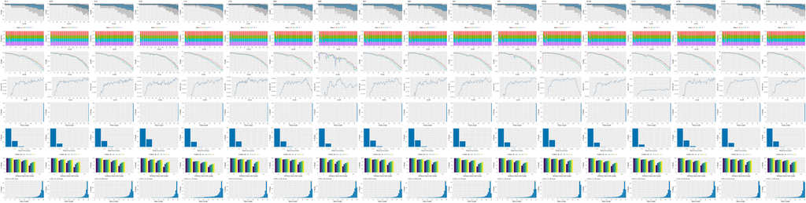

Figure 1: FASTQ quality report for 18 samples

```r
appendStep(sal) <- LineWise(code = {
    fastq <- getColumn(sal, step = "preprocessing", "targetsWF",
        column = 1)
    fqlist <- seeFastq(fastq = fastq, batchsize = 10000, klength = 8)
    png("./results/fastqReport.png", height = 1500, width = 330 *
        length(fqlist))
    seeFastqPlot(fqlist)
    dev.off()
}, step_name = "fastq_report", dependency = "preprocessing")
```

## 3.3 Short read alignments

### 3.3.1 Read mapping with `HISAT2`

To use the `HISAT2` short read aligner developed by Kim, Langmead, and Salzberg (2015), it is necessary to index the reference genome. `HISAT2` relies on the Burrows-Wheeler index for this process.

```r
appendStep(sal) <- SYSargsList(step_name = "hisat2_index", dir = FALSE,
    targets = NULL, wf_file = "hisat2/hisat2-index.cwl", input_file = "hisat2/hisat2-index.yml",
    dir_path = "param/cwl", dependency = "load_SPR")
```

### 3.3.2 `HISAT2` mapping

The parameter settings of the aligner are defined in the `cwl/yml` files used in the following code chunk. The following shows how to construct the alignment step and append it to the `SAL` workflow container. Please note that the input (FASTQ) files used in this step are the output files generated by the preprocessing step (see above: `step_name = "preprocessing"`).

```r
appendStep(sal) <- SYSargsList(step_name = "hisat2_mapping",
    dir = TRUE, targets = "preprocessing", wf_file = "workflow-hisat2/workflow_hisat2-pe.cwl",
    input_file = "workflow-hisat2/workflow_hisat2-pe.yml", dir_path = "param/cwl",
    inputvars = c(preprocessReads_1 = "_FASTQ_PATH1_", preprocessReads_2 = "_FASTQ_PATH2_",
        SampleName = "_SampleName_"), rm_targets_col = c("FileName1",
        "FileName2"), dependency = c("preprocessing", "hisat2_index"))
```

The `cmdlist` functions allows to inspect the exact CL call used for each input file (sample), here for `HISAT2` alignments. Note, this step also includes the conversion of the alignment files to sorted and indexed bam files using functionalities of the `SAMtools` CL suite.

```r
cmdlist(sal, step = "hisat2_mapping", targets = 1)
```

```r
$hisat2_mapping
$hisat2_mapping$M1A
$hisat2_mapping$M1A$hisat2
[1] "hisat2 -S ./results/M1A.sam  -x ./data/tair10.fasta  -k 1  --min-intronlen
30  --max-intronlen 3000  -1 ./results/preprocessing/M1A_1.fastq_trim.gz -2 ./results/preprocessing/M1A_2.fastq_trim.gz --threads 4"

$hisat2_mapping$M1A$`samtools-view`
[1] "samtools view -bS -o ./results/M1A.bam  ./results/M1A.sam "

$hisat2_mapping$M1A$`samtools-sort`
[1] "samtools sort -o ./results/M1A.sorted.bam  ./results/M1A.bam  -@ 4"

$hisat2_mapping$M1A$`samtools-index`
[1] "samtools index -b results/M1A.sorted.bam  results/M1A.sorted.bam.bai  ./res
ults/M1A.sorted.bam "
```

### 3.3.3 Alignment stats

The following computes an alignment summary file (here `alignStats.xls`), which comprises the count of reads in each FASTQ file and the number of reads that align with the reference, presented in both total and percentage values.

```r
appendStep(sal) <- LineWise(code = {
    fqpaths <- getColumn(sal, step = "preprocessing", "targetsWF",
        column = "FileName1")
    bampaths <- getColumn(sal, step = "hisat2_mapping", "outfiles",
        column = "samtools_sort_bam")
    read_statsDF <- alignStats(args = bampaths, fqpaths = fqpaths,
        pairEnd = TRUE)
    write.table(read_statsDF, "results/alignStats.xls", row.names = FALSE,
        quote = FALSE, sep = "\t")
}, step_name = "align_stats", dependency = "hisat2_mapping")
```

The resulting `alignStats.xls` file can be included in the report as shown below (here restricted to the first four rows).

```r
read.table("results/alignStats.xls", header = TRUE)[1:4, ]
```

```
##   FileName Nreads2x Nalign Perc_Aligned Nalign_Primary
## 1      M1A   115994 109977     94.81266         109977
## 2      M1B   134480 112464     83.62879         112464
## 3      A1A   127976 122427     95.66403         122427
## 4      A1B   122486 101369     82.75966         101369
##   Perc_Aligned_Primary
## 1             94.81266
## 2             83.62879
## 3             95.66403
## 4             82.75966
```

## 3.4 Viewing BAM files in IGV

The `symLink2bam` function creates symbolic links to view the BAM alignment files in a genome browser such as IGV without moving these large files to a local system. The corresponding URLs are written to a file with a path specified under `urlfile`, here `IGVurl.txt`. Please replace the directory and the user name.

The `symLink2bam` function creates symbolic links to view the BAM alignment files in a genome browser such as IGV without moving these large files to a local system. The corresponding URLs are written to a file with a path specified under `urlfile`, here `IGVurl.txt`. To make the following code work, users need to change the directory name (here `<somedir>`), and the url base and user names (here `<base_url>` and `<username>`) to the corresponding names on their system.

```r
appendStep(sal) <- LineWise(code = {
    bampaths <- getColumn(sal, step = "hisat2_mapping", "outfiles",
        column = "samtools_sort_bam")
    symLink2bam(sysargs = bampaths, htmldir = c("~/.html/", "<somedir>/"),
        urlbase = "<base_url>/~<username>/", urlfile = "./results/IGVurl.txt")
}, step_name = "bam_IGV", dependency = "hisat2_mapping", run_step = "optional")
```

## 3.5 Read quantification

Reads overlapping with annotation ranges of interest are counted for each sample using the `featureCounts` function. Most often the read counting is preformed for exonic gene regions. This can be done in a strand-specific or non-strand-specific manner, while accounting for overlaps among adjacent genes or ignoring them. Subsequently, the expression count values can be normalized with different methods.

### 3.5.1 Gene annotation database

For efficient handling of annotation ranges obtained from GFF or GTF files, they are organized within a `TxDb` object. Subsequently, the object is written to a SQLite database file. It is important to note that this process only needs to be performed once for a specific version of an annotation file.

```r
appendStep(sal) <- LineWise(code = {
    library(txdbmaker)
    txdb <- suppressWarnings(makeTxDbFromGFF(file = "data/tair10.gff",
        format = "gff", dataSource = "TAIR", organism = "Arabidopsis thaliana"))
    saveDb(txdb, file = "./data/tair10.sqlite")
}, step_name = "create_db", dependency = "hisat2_mapping")
```

### 3.5.2 Read Counting with `featureCounts`

```r
appendStep(sal) <- LineWise(code = {
    library(GenomicFeatures)
    library(Rsubread)
    txdb <- loadDb("./data/tair10.sqlite")
    eByg <- exonsBy(txdb, by = "gene")
    ## Helper: convert GRangesList or GRanges to data.frame
    ## for featureCounts
    grl_to_df <- function(grl) {
        gr <- unlist(grl)
        data.frame(GeneID = names(gr), Chr = as.character(seqnames(gr)),
            Start = start(gr), End = end(gr), Strand = as.character(strand(gr)),
            stringsAsFactors = FALSE)
    }
    outpaths <- getColumn(sal, step = "hisat2_mapping", "outfiles",
        column = "samtools_sort_bam")
    ## featureCounts accepts GRangesList directly via
    ## annot.ext strandSpecific=0: unstranded; 1: sense
    ## strand; 2: antisense strand Set strandSpecific=1 or
    ## 2 for strand-specific library preparations
    fc <- featureCounts(files = outpaths, annot.ext = grl_to_df(eByg),
        isGTFAnnotationFile = FALSE, useMetaFeatures = TRUE,
        strandSpecific = 0, isPairedEnd = TRUE, countMultiMappingReads = FALSE,
        nthreads = 4)
    countDFeByg <- fc$counts
    ## Assign sample names from outpaths
    colnames(countDFeByg) <- names(outpaths)
    ## Compute RPKM values eByg widths: sum of exon widths
    ## per gene for length normalization
    geneLengths <- sum(width(reduce(eByg)))
    rpkmDFeByg <- apply(countDFeByg, 2, function(x) returnRPKM(counts = x,
        ranges = eByg))
    ## Write count and RPKM tables to results directory
    write.table(countDFeByg, "results/countDFeByg.xls", col.names = NA,
        quote = FALSE, sep = "\t")
    write.table(rpkmDFeByg, "results/rpkmDFeByg.xls", col.names = NA,
        quote = FALSE, sep = "\t")
    ## Creating a SummarizedExperiment object
    colData <- data.frame(row.names = SampleName(sal, "hisat2_mapping"),
        condition = getColumn(sal, "hisat2_mapping", position = "targetsWF",
            column = "Factor"))
    colData$condition <- factor(colData$condition)
    countDF_se <- SummarizedExperiment::SummarizedExperiment(assays = countDFeByg,
        colData = colData)
    ## Add results as SummarizedExperiment to the workflow
    ## object
    SE(sal, "read_counting") <- countDF_se
}, step_name = "read_counting", dependency = "create_db")
```

Importantly, when conducting statistical differential expression or abundance analysis using methods like `edgeR` or `DESeq2`, the raw count values are the expected input. RPKM values should be reserved for specialized applications, such as manually inspecting expression levels across different genes or features.

Shows first 10 rows of `countDFeByg.xls` table.

```r
read.delim("results/countDFeByg.xls", row.names = 1, check.names = FALSE)[1:10,
    ]
```

```
##           M1A  M1B  A1A A1B  V1A V1B M6A M6B A6A A6B  V6A
## AT1G01010 301  365  390 255  617 311 271 152 554 338  807
## AT1G01020 121  211  157 209  199 166 166 155 127 118  226
## AT1G01030 138  159  181  94  173 211  80  32  30  82  124
## AT1G01040 954 1069 1078 990 1117 926 928 653 924 696 1713
## AT1G01046  13    3    9   1    4   2  14   6  16  10   16
## AT1G01050 193  224  254 220  264 386 564 677 402 459  645
## AT1G01060 115  478   92 116   38  37   9   4   7   4    2
## AT1G01070   0    1    5   5   11   5  13  14  30   8   31
## AT1G01073   0    0    0   0    0   0   0   0   0   0    0
## AT1G01080 412  635  403 651  554 675 500 833 291 389  410
##            V6B M12A M12B A12A A12B V12A V12B
## AT1G01010  601  229  273  554  473  690  749
## AT1G01020  260   73  188  143  139   85  180
## AT1G01030  250   57   67   36   66  191  525
## AT1G01040 1684  710 1146 1393  766  704 1073
## AT1G01046   10    3    6   22    2    5    5
## AT1G01050 1036  749 1485  769  589  667 1099
## AT1G01060   12  242  362  544  225  177  181
## AT1G01070   16   15   67   67   45   24   26
## AT1G01073    0    0    0    0    0    0    0
## AT1G01080  867  477 1193  381  353  288  435
```

### 3.5.3 Sample-wise clustering

The sample-wise Spearman correlation coefficients are calculated from the `rlog` transformed expression values (`countDF_se`) generated using the `DESeq2` package. These values are then converted into a distance matrix, which is subsequently used for hierarchical clustering with the `hclust` function. The resulting dendrogram is then saved as a PNG file named `sample_tree.png`.

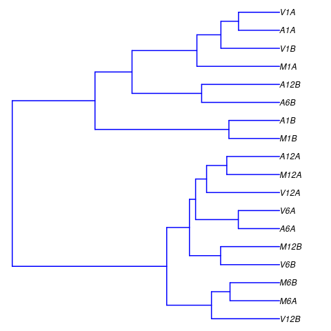

```r
appendStep(sal) <- LineWise(code = {
    library(DESeq2, quietly = TRUE)
    library(ape, warn.conflicts = FALSE)
    ## Extracting SummarizedExperiment object
    se <- SE(sal, "read_counting")
    dds <- DESeqDataSet(se, design = ~condition)
    d <- cor(assay(rlog(dds)), method = "spearman")
    hc <- hclust(dist(1 - d))
    png("results/sample_tree.png")
    plot.phylo(as.phylo(hc), type = "p", edge.col = "blue", edge.width = 2,
        show.node.label = TRUE, no.margin = TRUE)
    dev.off()
}, step_name = "sample_tree", dependency = "read_counting")
```

Figure 2: Correlation dendrogram of samples

## 3.6 Analysis of DEGs

The analysis of differentially expressed genes (DEGs) is performed with the `glm` method of the `edgeR` package (Robinson, McCarthy, and Smyth 2010). The sample comparisons used by this analysis are defined in the header lines of the `targets.txt` file starting with `<CMP>`.

### 3.6.1 Run `edgeR`

```r
appendStep(sal) <- LineWise(code = {
    library(edgeR)
    countDF <- read.delim("results/countDFeByg.xls", row.names = 1,
        check.names = FALSE)
    cmp <- readComp(stepsWF(sal)[["hisat2_mapping"]], format = "matrix",
        delim = "-")
    edgeDF <- run_edgeR(countDF = countDF, targets = targetsWF(sal)[["hisat2_mapping"]],
        cmp = cmp[[1]], independent = FALSE, mdsplot = "")
    write.table(edgeDF, "./results/edgeRglm_allcomp.xls", quote = FALSE,
        sep = "\t", col.names = NA)
}, step_name = "run_edger", dependency = "read_counting")
```

Note, to call DEGs with `DESeq2` instead of `edgeR`, users can simply replace in the above code ‘`run_edgeR`’ with ‘`run_DESeq2`’.

### 3.6.2 Add gene descriptions

This step is optional. It appends functional descriptions obtained from BioMart to the DEG table.

```r
appendStep(sal) <- LineWise(code = {
    library("biomaRt")
    m <- useMart("plants_mart", dataset = "athaliana_eg_gene",
        host = "https://plants.ensembl.org")
    desc <- getBM(attributes = c("tair_locus", "description"),
        mart = m)
    desc <- desc[!duplicated(desc[, 1]), ]
    descv <- as.character(desc[, 2])
    names(descv) <- as.character(desc[, 1])
    edgeDF <- data.frame(edgeDF, Desc = descv[rownames(edgeDF)],
        check.names = FALSE)
    write.table(edgeDF, "./results/edgeRglm_allcomp.xls", quote = FALSE,
        sep = "\t", col.names = NA)
}, step_name = "custom_annot", dependency = "run_edger")
```

### 3.6.3 Plot DEG results

Filter and plot DEG results for up and down regulated genes. The definition of *up* and *down* is given in the corresponding help file. To open it, type `?filterDEGs` in the R console.

Note, due to the small number of genes in the toy dataset, the FDR cutoff in this example is set to an unreasonably large value. With real data sets this cutoff should be set to a much smaller value (often 1%, 5% or 10%).

```r
appendStep(sal) <- LineWise(code = {
    edgeDF <- read.delim("results/edgeRglm_allcomp.xls", row.names = 1,
        check.names = FALSE)
    png("results/DEGcounts.png")
    DEG_list <- filterDEGs(degDF = edgeDF, filter = c(Fold = 2,
        FDR = 20))
    dev.off()
    write.table(DEG_list$Summary, "./results/DEGcounts.xls",
        quote = FALSE, sep = "\t", row.names = FALSE)
}, step_name = "filter_degs", dependency = "custom_annot")
```

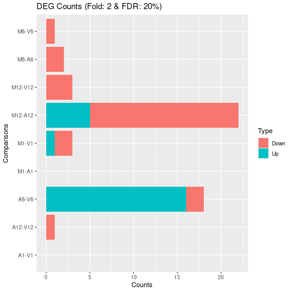

Figure 3: Up and down regulated DEGs.

### 3.6.4 Venn diagrams of DEG sets

The `overLapper` function can compute Venn intersects for large numbers of sample sets (up to 20 or more) and plots 2-5 way Venn diagrams. A useful feature is the possibility to combine the counts from several Venn comparisons with the same number of sample sets in a single Venn diagram (here for 4 up and down DEG sets).

The overLapper function can compute Venn intersects for large numbers of sample sets (up to 20 or more) and plots 2-5 way Venn diagrams. A useful feature is the possibility to combine the counts from several Venn comparisons with the same number of sample sets in a single Venn diagram (here for 4 up and down DEG sets).

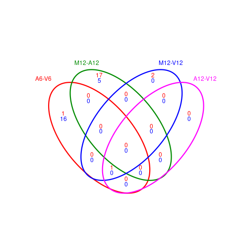

```r
appendStep(sal) <- LineWise(code = {
    vennsetup <- overLapper(DEG_list$Up[6:9], type = "vennsets")
    vennsetdown <- overLapper(DEG_list$Down[6:9], type = "vennsets")
    png("results/vennplot.png")
    vennPlot(list(vennsetup, vennsetdown), mymain = "", mysub = "",
        colmode = 2, ccol = c("blue", "red"))
    dev.off()
}, step_name = "venn_diagram", dependency = "filter_degs")
```

Figure 4: Venn Diagram for 4 Up and Down DEG Sets

## 3.7 GO term enrichment analysis

### 3.7.1 Obtain gene-to-GO mappings

The following shows how to obtain gene-to-GO mappings from `biomaRt` (here for *A. thaliana*) and how to organize them for the downstream GO term enrichment analysis. Alternatively, the gene-to-GO mappings can be obtained for many organisms from Bioconductor’s `*.db` genome annotation packages or GO annotation files provided by various genome databases. For each annotation this relatively slow preprocessing step needs to be performed only once. Subsequently, the preprocessed data can be loaded with the `load` function as shown in the next subsection.

```r
appendStep(sal) <- LineWise(code = {
    library("biomaRt")
    # listMarts() # To choose BioMart database
    # listMarts(host='plants.ensembl.org')
    m <- useMart("plants_mart", host = "https://plants.ensembl.org")
    # listDatasets(m)
    m <- useMart("plants_mart", dataset = "athaliana_eg_gene",
        host = "https://plants.ensembl.org")
    # listAttributes(m) # Choose data types you want to
    # download
    go <- getBM(attributes = c("go_id", "tair_locus", "namespace_1003"),
        mart = m)
    go <- go[go[, 3] != "", ]
    go[, 3] <- as.character(go[, 3])
    go[go[, 3] == "molecular_function", 3] <- "F"
    go[go[, 3] == "biological_process", 3] <- "P"
    go[go[, 3] == "cellular_component", 3] <- "C"
    go[1:4, ]
    if (!dir.exists("./data/GO"))
        dir.create("./data/GO")
    write.table(go, "data/GO/GOannotationsBiomart_mod.txt", quote = FALSE,
        row.names = FALSE, col.names = FALSE, sep = "\t")
    catdb <- makeCATdb(myfile = "data/GO/GOannotationsBiomart_mod.txt",
        lib = NULL, org = "", colno = c(1, 2, 3), idconv = NULL)
    save(catdb, file = "data/GO/catdb.RData")
}, step_name = "get_go_annot", dependency = "filter_degs")
```

### 3.7.2 Batch GO term enrichment analysis

Apply the enrichment analysis to the DEG sets obtained the above differential expression analysis. Note, in the following example the `FDR` filter is set here to an unreasonably high value, simply because of the small size of the toy data set used in this vignette. Batch enrichment analysis of many gene sets is performed with the `GOCluster_Report` function. When `method=all`, it returns all GO terms passing the p-value cutoff specified under the `cutoff` arguments. When `method=slim`, it returns only the GO terms specified under the `myslimv` argument. The given example shows how a GO slim vector for a specific organism can be obtained from `BioMart`.

```r
appendStep(sal) <- LineWise(code = {
    library("biomaRt")
    load("data/GO/catdb.RData")
    DEG_list <- filterDEGs(degDF = edgeDF, filter = c(Fold = 2,
        FDR = 50), plot = FALSE)
    up_down <- DEG_list$UporDown
    names(up_down) <- paste(names(up_down), "_up_down", sep = "")
    up <- DEG_list$Up
    names(up) <- paste(names(up), "_up", sep = "")
    down <- DEG_list$Down
    names(down) <- paste(names(down), "_down", sep = "")
    DEGlist <- c(up_down, up, down)
    DEGlist <- DEGlist[sapply(DEGlist, length) > 0]
    BatchResult <- GOCluster_Report(catdb = catdb, setlist = DEGlist,
        method = "all", id_type = "gene", CLSZ = 2, cutoff = 0.9,
        gocats = c("MF", "BP", "CC"), recordSpecGO = NULL)
    m <- useMart("plants_mart", dataset = "athaliana_eg_gene",
        host = "https://plants.ensembl.org")
    goslimvec <- as.character(getBM(attributes = c("goslim_goa_accession"),
        mart = m)[, 1])
    BatchResultslim <- GOCluster_Report(catdb = catdb, setlist = DEGlist,
        method = "slim", id_type = "gene", myslimv = goslimvec,
        CLSZ = 10, cutoff = 0.01, gocats = c("MF", "BP", "CC"),
        recordSpecGO = NULL)
    write.table(BatchResultslim, "results/GOBatchSlim.xls", row.names = FALSE,
        quote = FALSE, sep = "\t")
}, step_name = "go_enrich", dependency = "get_go_annot")
```

### 3.7.3 Plot batch GO term results

The `data.frame` generated by `GOCluster` can be plotted with the `goBarplot` function. Because of the variable size of the sample sets, it may not always be desirable to show the results from different DEG sets in the same bar plot. Plotting single sample sets is achieved by subsetting the input data frame as shown in the first line of the following example.

```r
appendStep(sal) <- LineWise(code = {
    gos <- BatchResultslim[grep("M6-V6_up_down", BatchResultslim$CLID),
        ]
    gos <- BatchResultslim
    png("results/GOslimbarplotMF.png", height = 8, width = 10)
    goBarplot(gos, gocat = "MF")
    goBarplot(gos, gocat = "BP")
    goBarplot(gos, gocat = "CC")
    dev.off()
}, step_name = "go_plot", dependency = "go_enrich")
```

## 3.8 Clustering and heat maps

The following example performs hierarchical clustering on the `rlog` transformed expression matrix subsetted by the DEGs identified in the above differential expression analysis. It uses a Pearson correlation-based distance measure and complete linkage for cluster joining.

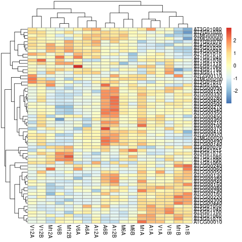

```r
appendStep(sal) <- LineWise(code = {
    library(pheatmap)
    geneids <- unique(as.character(unlist(DEG_list[[1]])))
    y <- assay(rlog(dds))[geneids, ]
    png("results/heatmap1.png")
    pheatmap(y, scale = "row", clustering_distance_rows = "correlation",
        clustering_distance_cols = "correlation")
    dev.off()
}, step_name = "heatmap", dependency = "go_enrich")
```

Figure 6: Heat Map with Hierarchical Clustering Dendrograms of DEGs

## 3.9 Workflow session information

```r
appendStep(sal) <- LineWise(code = {
    sessionInfo()
}, step_name = "sessionInfo", dependency = "heatmap")
```

# 4 Additional details

## 4.1 Running workflows

The `runWF` function is the primary tool for executing workflows. It runs the code of the workflow steps after loading them into a `SAL` workflow container. The workflow steps can be loaded interactively one by one or in batch mode with the `importWF` function. The batch mode is more convenient and is the intended method for loading workflows. It is part of the standard routine for running workflows introduced in the Quick start section.

### 4.1.1 Parallelization on clusters

The processing time of computationally expensive steps can be greatly accelerated by processing many input files in parallel using several CPUs and/or computer nodes of an HPC or cloud system, where a scheduling system is used for load balancing. To simplify for users the configuration and execution of workflow steps in serial or parallel mode, `systemPipeR` uses for both the same `runWF` function. Parallelization simply requires appending of the parallelization parameters to the settings of the corresponding workflow steps each requesting the computing resources specified by the user, such as the number of CPU cores, RAM and run time. These resource settings are stored in the corresponding workflow step of the `SAL` workflow container. After adding the parallelization parameters, `runWF` will execute the chosen steps in parallel mode as instructed.

The following example applies to an alignment step of an RNA-Seq workflow. In the chosen alignment example, the parallelization parameters are added to the alignment step (here `hisat2_mapping`) of `SAL` via a `resources` list. The given parameter settings will run 18 processes (`Njobs`) in parallel using for each 4 CPU cores (`ncpus`), thus utilizing a total of 72 CPU cores. The `runWF` function can be used with most queueing systems as it is based on utilities defined by the `batchtools` package, which supports the use of template files (*`*.tmpl`*) for defining the run parameters of different schedulers. In the given example below, a `conffile` (see *`.batchtools.conf.R`* samples [here](https://mllg.github.io/batchtools/)) and a `template` file (see *`*.tmpl`* samples [here](https://github.com/mllg/batchtools/tree/master/inst/templates)) need to be present on the highest level of a user’s workflow project. The following example uses the sample `conffile` and `template` files for the Slurm scheduler that are both provided by this package.

The `resources` list can be added to analysis steps when a workflow is loaded into `SAL`. Alternatively, one can add the resource settings with the `addResources` function to any step of a pre-populated `SAL` container afterwards. For workflow steps with the same resource requirements, one can add them to several steps at once with a single call to `addResources` by specifying multiple step names under the `step` argument.

```r
resources <- list(conffile = ".batchtools.conf.R", template = "batchtools.slurm.tmpl",
    Njobs = 18, walltime = 120, ntasks = 1, ncpus = 4, memory = 1024,
    partition = "short")
sal <- addResources(sal, step = c("hisat2_mapping"), resources = resources)
sal <- runWF(sal)
```

The above example will submit via `runWF(sal)` the *hisat2_mapping* step to a partition (queue) called `short` on an HPC cluster. Users need to adjust this and other parameters, that are defined in the `resources` list, to their cluster environment .

## 4.2 CL tools used

The `listCmdTools` (and `listCmdModules`) return the CL tools that are used by a workflow. To include a CL tool list in a workflow report, one can use the following code. Additional details on this topic can be found in the main vignette [here](https://www.bioconductor.org/packages/devel/bioc/vignettes/systemPipeR/inst/doc/systemPipeR.html#111_Accessor_methods).

```r
if (file.exists(file.path(".SPRproject", "SYSargsList.yml"))) {
    local({
        sal <- systemPipeR::SPRproject(resume = TRUE)
        systemPipeR::listCmdTools(sal)
        systemPipeR::listCmdModules(sal)
    })
} else {
    cat(crayon::blue$bold("Tools and modules required by this workflow are:\n"))
    cat(c("gzip", "gunzip"), sep = "\n")
}
```

```
## Creating file '/bigdata/gen242/tgirke/2026/rnaseq/genWorkenvir_gh_R4.6/rnaseq/.SPRproject/SYSargsList.yml'
## Following tools are used in steps in this workflow:
##        step_name         tool in_path
## 1  preprocessing      Rscript      NA
## 2       trimming  trimmomatic      NA
## 3   hisat2_index hisat2-build      NA
## 4 hisat2_mapping       hisat2      NA
## 5 hisat2_mapping     samtools      NA
## 6 hisat2_mapping     samtools      NA
## 7 hisat2_mapping     samtools      NA
## Here are modules used in this workflow:
##        step_name           module avail
## 1       trimming trimmomatic/0.39    NA
## 2   hisat2_index     hisat2/2.1.0    NA
## 3 hisat2_mapping     hisat2/2.1.0    NA
## 4 hisat2_mapping    samtools/1.14    NA
```

# 5 Funding

This project is funded by awards from the National Science Foundation ([ABI-1661152](https://www.nsf.gov/awardsearch/showAward?AWD_ID=1661152)], and the National Institute on Aging of the National Institutes of Health ([U19AG023122](https://reporter.nih.gov/project-details/9632486)).

# References

Bolger, Anthony M, Marc Lohse, and Bjoern Usadel. 2014. “Trimmomatic: A Flexible Trimmer for Illumina Sequence Data.” *Bioinformatics* 30 (15): 2114–20.

H Backman, Tyler W, and Thomas Girke. 2016. “systemPipeR: NGS workflow and report generation environment.” *BMC Bioinformatics* 17 (1): 388. https://doi.org/10.1186/s12859-016-1241-0.

Howard, Brian E, Qiwen Hu, Ahmet Can Babaoglu, Manan Chandra, Monica Borghi, Xiaoping Tan, Luyan He, et al. 2013. “High-Throughput RNA Sequencing of Pseudomonas-Infected Arabidopsis Reveals Hidden Transcriptome Complexity and Novel Splice Variants.” *PLoS One* 8 (10): e74183. https://doi.org/10.1371/journal.pone.0074183.

Kim, Daehwan, Ben Langmead, and Steven L Salzberg. 2015. “HISAT: A Fast Spliced Aligner with Low Memory Requirements.” *Nat. Methods* 12 (4): 357–60.

Liao, Yang, Gordon K Smyth, and Wei Shi. 2013. “The Subread Aligner: Fast, Accurate and Scalable Read Mapping by Seed-and-Vote.” *Nucleic Acids Res.* 41 (10): e108. https://doi.org/10.1093/nar/gkt214.

Robinson, M D, D J McCarthy, and G K Smyth. 2010. “edgeR: A Bioconductor Package for Differential Expression Analysis of Digital Gene Expression Data.” *Bioinformatics* 26 (1): 139–40. https://doi.org/10.1093/bioinformatics/btp616.

Zhang, Le, Daniela Cassol, Brendan Gongol, and Thomas Girke. 2026. “systemPipeR: a multipurpose workflow management system for reproducible data analysis.” *NAR Genom. Bioinform.* 8 (2): lqag032. https://doi.org/10.1093/nargab/lqag032.